# R Notebook

```r
library(here)
library(tidyverse)
library(ggpubr)
library(epitools)
pal2 <- c("#015b58", "#5962b5")
pal2.flip <- c("#5962b5", "#015b58")
here::here()
```

```
[1] "/Users/emma/Library/CloudStorage/OneDrive-SharedLibraries-IndianaUniversity/Lennon, Jay - 0000_Bueren/Projects/LifeStyle/PhageLifestyleSporulation"
```

```r
box <- read.delim2(here("data/inphared_db/14Apr2025inph_0A_v3.txt" ))
box <- subset(box, box$Header!="Header")
box <- box %>% rename(product = Sequence, phage = Contig)
box[,c(2)] <- "0A_box"
#box <- box[,c(3,2,1)]
box$count <- 1


gc_content <- function(seq) {
  seq <- toupper(seq)
  bases <- strsplit(seq, "")[[1]]
  gc_count <- sum(bases %in% c("G", "C"))
  total <- length(bases)
  return(gc_count / total)
}

# Vectorized version for multiple sequences
gc_content_vec <- function(seqs) {
  sapply(seqs, gc_content)
}


box$GC.flanks <- gc_content_vec(box$Upstream)


box <- subset(box, box$GC.flanks<0.35)


box.all <- box

box <-  box.all %>% group_by(phage, product) %>% summarise(sum=sum(count))
phage <- read.csv(here("data/inphared_db/14Apr2025_knownsporestatus.csv"), row.names=1)




all <- merge(box, phage, by.x="phage", by.y="Accession", all.x=TRUE, all.y=TRUE)


all$product[is.na(all$product)] <- "0A_box"


all$sum[is.na(all$sum)] <- 0

all[is.na(all)] <- "currently_missing"
all <- subset(all, all$newgtdb_Phylum!="currently_missing")

all$HostPhyla <- "Other"
all$HostPhyla <- ifelse(all$newgtdb_Phylum=="Bacillota", "Bacillota", "Other")

all$sporulation <- "unknown"
all$sporulation <- ifelse(all$f_spor=="TRUE", "Spor", all$sporulation)
all$sporulation <- ifelse(all$f_spor=="FALSE", "Nonspor", all$sporulation)

all <- subset(all, all$sporulation!="unknown" )
all <- subset(all, all$predicted_label!="missing")

all <- unite(all, "phyla_spor_type", c("HostPhyla", "sporulation", "lifestyle"), sep = "_", remove = FALSE, na.rm = FALSE)

all <- unite(all, "spor_type", c("sporulation", "lifestyle"), sep = "_", remove = FALSE, na.rm = FALSE)

all <- unite(all, "specphyla_spor_type", c("newgtdb_Phylum", "sporulation", "lifestyle"), sep = "_", remove = FALSE, na.rm = FALSE)


all$genome <- as.numeric(all$Genome.Length..bp.)
all$GC <- as.numeric(all$molGC....)
all$genome <- log10(all$genome)
```

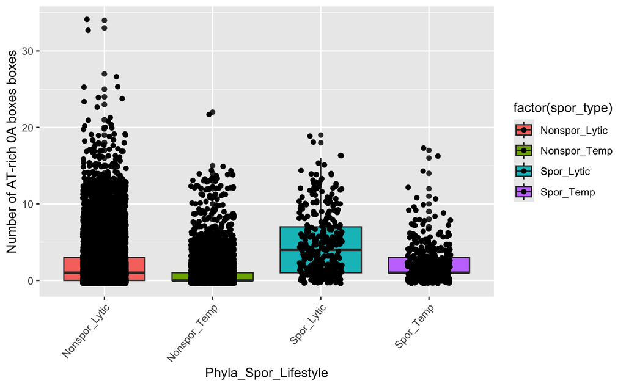

```r
all$tally <- 1
all$hit <- ifelse(all$sum!=0, 1, 0)

counts <- all %>% group_by(phyla_spor_type) %>% summarise(num.phage=sum(tally), total.0A=sum(sum), mean.0A=mean(sum), hits.0A=sum(hit))


### only accounting for sporulation and lifestyle
ggplot(all, aes(x = factor(spor_type), fill = factor(spor_type), y = sum )) +
  geom_boxplot(binaxis = "y", stackdir = "center", position = "dodge") + geom_jitter(width = 0.2) + ylab("Number of AT-rich 0A boxes boxes") +theme(axis.text.x = element_text(angle = 50, vjust = 1, hjust = 1)) + theme(legend.position = "right") + xlab("Phyla_Spor_Lifestyle")
```

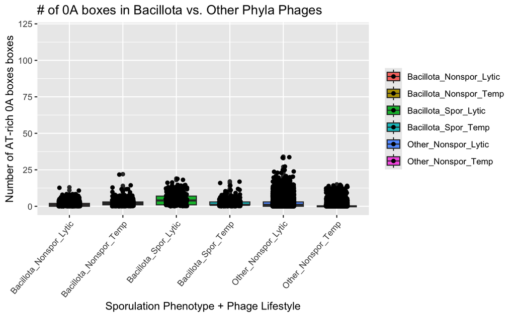

```r
## accounting for bacilliota vs. other phyla
ggplot(all, aes(x = factor(phyla_spor_type), fill = factor(phyla_spor_type), y = sum )) +
  geom_boxplot(binaxis = "y", stackdir = "center", position = "dodge") + geom_jitter(width = 0.2) + ylab("Number of AT-rich 0A boxes boxes")+theme(axis.text.x = element_text(angle = 50, vjust = 1, hjust = 1)) + theme(legend.position = "right", legend.title = element_blank()) + xlab("Sporulation Phenotype + Phage Lifestyle") + ggtitle(("# of 0A boxes in Bacillota vs. Other Phyla Phages")) +ylim(0,120)
ggsave(here("lab_pres/UpstreamFilt35_Inph0ACounts.png"))
```

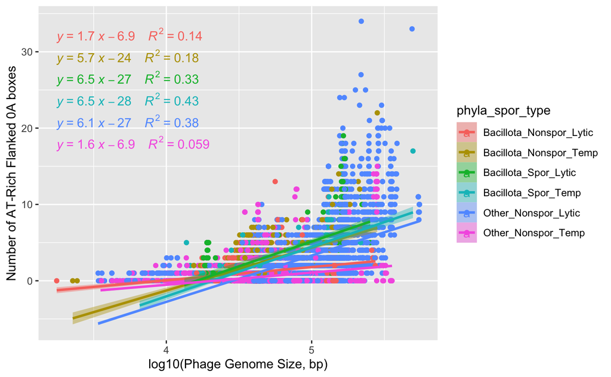

```r
## linear reg

ggplot(all, aes(genome,sum, fill=phyla_spor_type, colour = phyla_spor_type)) +
  geom_point() +
   geom_smooth(method="lm")+ # Add regression line
 stat_regline_equation(aes(label = paste(..eq.label.., ..rr.label.., sep = "~~~~")),
                        label.x.npc = "left", label.y.npc = "top" )   + ylab("Number of AT-Rich Flanked 0A boxes") +xlab("log10(Phage Genome Size, bp)")# Add

ggsave(here("lab_pres/UpstreamFilt35_Inph0AReg.png"))
```

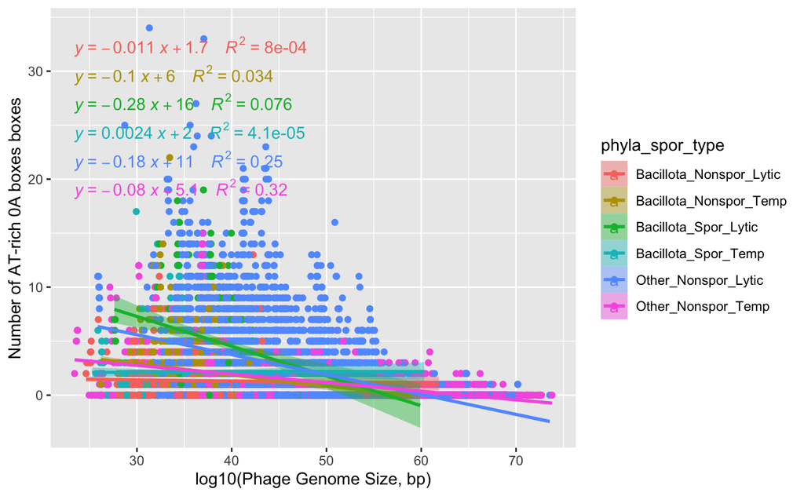

```r
ggplot(all, aes(GC,sum, fill=phyla_spor_type, colour = phyla_spor_type)) +
  geom_point() +
   geom_smooth(method="lm")+ # Add regression line
 stat_regline_equation(aes(label = paste(..eq.label.., ..rr.label.., sep = "~~~~")),
                        label.x.npc = "left", label.y.npc = "top" )   + ylab("Number of AT-rich 0A boxes boxes") +xlab("log10(Phage Genome Size, bp)")# Add
ggsave(here("lab_pres/UpstreamFilt35_Inph0AReg-GC.png"))
```

## accounting for bacilliota vs. other phyla

ggplot(all, aes(x = factor(newgtdb_Phylum), fill = factor(predicted_label), y = sum )) + geom_boxplot(binaxis = “y”, stackdir = “center”, position = “dodge”) + geom_jitter(width = 0.2) + ylab(“Number of AT-rich 0A boxes boxes”)

ggplot(all, aes(x = factor(specphyla_spor_type), fill = factor(predicted_label), y = sum )) + geom_boxplot(binaxis = “y”, stackdir = “center”, position = “dodge”) + geom_jitter(width = 0.2) + ylab(“Number of AT-rich 0A boxes boxes”)

## accounting for bacilliota vs. other phyla

ggplot(all, aes(x = factor(phyla_spor_type), fill = factor(phyla_spor_type), y = sum )) + geom_boxplot(binaxis = “y”, stackdir = “center”, position = “dodge”) + geom_jitter(width = 0.2) + ylab(“Number of AT-rich 0A boxes boxes”) +theme(axis.text.x = element_text(angle = 50, vjust = 1, hjust = 1)) + theme(legend.position = “left”) + xlab(“Phyla_Spor_Lifestyle”)

ggplot(all, aes(x = factor(specphyla_spor_type), fill = factor(specphyla_spor_type), y = sum )) + geom_boxplot(binaxis = “y”, stackdir = “center”, position = “dodge”) + geom_jitter(width = 0.2) + ylab(“Number of AT-rich 0A boxes boxes”)

```r
a1 <- aov(sum ~ phyla_spor_type, data = all)
summary(a1)
```

```
                   Df Sum Sq Mean Sq F value Pr(>F)
phyla_spor_type     5  16889    3378   515.4 <2e-16 ***
Residuals       20516 134462       7
---
Signif. codes:  0 ‘***’ 0.001 ‘**’ 0.01 ‘*’ 0.05 ‘.’ 0.1 ‘ ’ 1
```

```r
TukeyHSD(a1)
```

```
  Tukey multiple comparisons of means
    95% family-wise confidence level

Fit: aov(formula = sum ~ phyla_spor_type, data = all)

$phyla_spor_type
                                                      diff         lwr        upr     p adj
Bacillota_Nonspor_Temp-Bacillota_Nonspor_Lytic  0.78755300  0.49493759  1.0801684 0.0000000
Bacillota_Spor_Lytic-Bacillota_Nonspor_Lytic    3.28620710  2.84163788  3.7307763 0.0000000
Bacillota_Spor_Temp-Bacillota_Nonspor_Lytic     0.76350198  0.35633808  1.1706659 0.0000013
Other_Nonspor_Lytic-Bacillota_Nonspor_Lytic     0.91293550  0.68075479  1.1451162 0.0000000
Other_Nonspor_Temp-Bacillota_Nonspor_Lytic     -0.83996481 -1.07625541 -0.6036742 0.0000000
Bacillota_Spor_Lytic-Bacillota_Nonspor_Temp     2.49865410  2.06713149  2.9301767 0.0000000
Bacillota_Spor_Temp-Bacillota_Nonspor_Temp     -0.02405102 -0.41692812  0.3688261 0.9999777
Other_Nonspor_Lytic-Bacillota_Nonspor_Temp      0.12538250 -0.08071906  0.3314841 0.5092498
Other_Nonspor_Temp-Bacillota_Nonspor_Temp      -1.62751781 -1.83823852 -1.4167971 0.0000000
Bacillota_Spor_Temp-Bacillota_Spor_Lytic       -2.52270512 -3.03881598 -2.0065943 0.0000000
Other_Nonspor_Lytic-Bacillota_Spor_Lytic       -2.37327160 -2.76633122 -1.9802120 0.0000000
Other_Nonspor_Temp-Bacillota_Spor_Lytic        -4.12617191 -4.52167314 -3.7306707 0.0000000
Other_Nonspor_Lytic-Bacillota_Spor_Temp         0.14943352 -0.20076145  0.4996285 0.8291778
Other_Nonspor_Temp-Bacillota_Spor_Temp         -1.60346679 -1.95640004 -1.2505335 0.0000000
Other_Nonspor_Temp-Other_Nonspor_Lytic         -1.75290031 -1.86553832 -1.6402623 0.0000000
```

```r
all.spor.counts  <- all %>% group_by(sporulation) %>% summarise(num.phage=sum(tally), total.0A=sum(sum), mean.0A=mean(sum), hits.0A=sum(hit))

all.spor.counts$perc.hit <- all.spor.counts$hits.0A/all.spor.counts$num.phage

all.spor.counts
```

| sporulation | num.phage | total.0A | mean.0A | hits.0A | perc.hit |
| --- | --- | --- | --- | --- | --- |
| Nonspor | 19711 | 30976 | 1.571508 | 9802 | 0.4972858 |
| Spor | 811 | 2628 | 3.240444 | 664 | 0.8187423 |

```r
spor.stat <- c('Spore', 'Non-spore')
outcome <- c('Hits', 'None')
all.hits <- matrix(c(736, 75, 18825, 887), nrow=2, ncol=2, byrow=TRUE)
dimnames(all.hits) <- list('Spore'=spor.stat, 'Outcome'=outcome)
all.hits
```

```
           Outcome
Spore        Hits None
  Spore       736   75
  Non-spore 18825  887
```

```r
fisher.test(all.hits)
```

```
    Fisher's Exact Test for Count Data

data:  all.hits
p-value = 2.102e-08
alternative hypothesis: true odds ratio is not equal to 1
95 percent confidence interval:
 0.3604635 0.6002062
sample estimates:
odds ratio
 0.4624162
```

```r
oddsratio(all.hits)
```

```
$data
           Outcome
Spore        Hits None Total
  Spore       736   75   811
  Non-spore 18825  887 19712
  Total     19561  962 20523

$measure
           odds ratio with 95% C.I.
Spore        estimate     lower     upper
  Spore     1.0000000        NA        NA
  Non-spore 0.4615714 0.3629677 0.5953388

$p.value
           two-sided
Spore         midp.exact fisher.exact   chi.square
  Spore               NA           NA           NA
  Non-spore 2.090057e-08 2.101833e-08 3.623752e-10

$correction
[1] FALSE

attr(,"method")
[1] "median-unbiased estimate & mid-p exact CI"
```

other phyla lifestyle

```r
phyla <- subset(all, all$HostPhyla=="OtherPhyla")


phyla.life <- phyla %>% group_by(predicted_label) %>% summarise(num.phage=sum(tally), total.0A=sum(sum), mean.0A=mean(sum), hits.0A=sum(hit))

phyla.life
```

| predicted_label | num.phage | total.0A | mean.0A | hits.0A |
| --- | --- | --- | --- | --- |

```r
NA
```

```r
phyla.stat <- c('Lytic', 'Temp')
outcome <- c('Hits', 'None')
phyla.hits <- matrix(c(7047, 239, 9544, 350), nrow=2, ncol=2, byrow=TRUE)
dimnames(phyla.hits) <- list('Lifestyle'=phyla.stat, 'Outcome'=outcome)
phyla.hits
```

```
         Outcome
Lifestyle Hits None
    Lytic 7047  239
    Temp  9544  350
```

```r
fisher.test(phyla.hits)
```

```
    Fisher's Exact Test for Count Data

data:  phyla.hits
p-value = 0.3731
alternative hypothesis: true odds ratio is not equal to 1
95 percent confidence interval:
 0.9119789 1.2837726
sample estimates:
odds ratio
   1.08131
```

```r
oddsratio(phyla.hits)
```

```
$data
         Outcome
Lifestyle  Hits None Total
    Lytic  7047  239  7286
    Temp   9544  350  9894
    Total 16591  589 17180

$measure
         odds ratio with 95% C.I.
Lifestyle estimate     lower    upper
    Lytic 1.000000        NA       NA
    Temp  1.081059 0.9150867 1.279243

$p.value
         two-sided
Lifestyle midp.exact fisher.exact chi.square
    Lytic         NA           NA         NA
    Temp     0.36041    0.3731368  0.3597985

$correction
[1] FALSE

attr(,"method")
[1] "median-unbiased estimate & mid-p exact CI"
```

##### BACILLIOTA ONLY

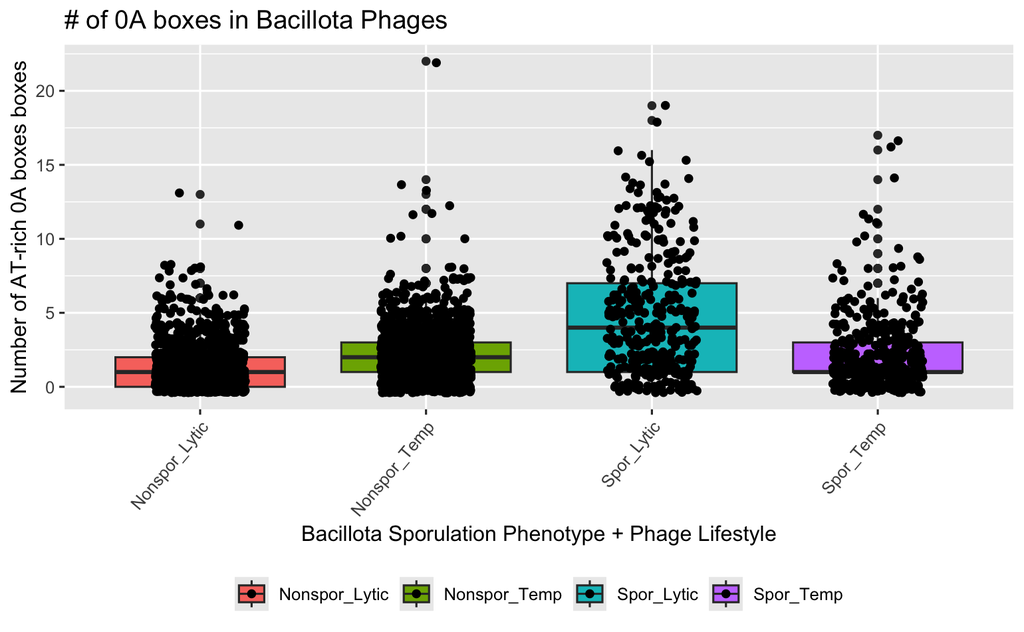

```r
baci <- subset(all, all$HostPhyla=="Bacillota")


ggplot(baci, aes(x = factor(spor_type), fill = factor(spor_type), y = sum )) +
  geom_boxplot(binaxis = "y", stackdir = "center", position = "dodge") + geom_jitter(width = 0.2) + ylab("Number of AT-rich 0A boxes boxes")+theme(axis.text.x = element_text(angle = 50, vjust = 1, hjust = 1)) + theme(legend.position = "bottom", legend.title = element_blank()) + xlab("Bacillota Sporulation Phenotype + Phage Lifestyle") + ggtitle(("# of 0A boxes in Bacillota Phages"))
ggsave(here("lab_pres/UpstreamFilt35_Baci0ACounts.png"))
```

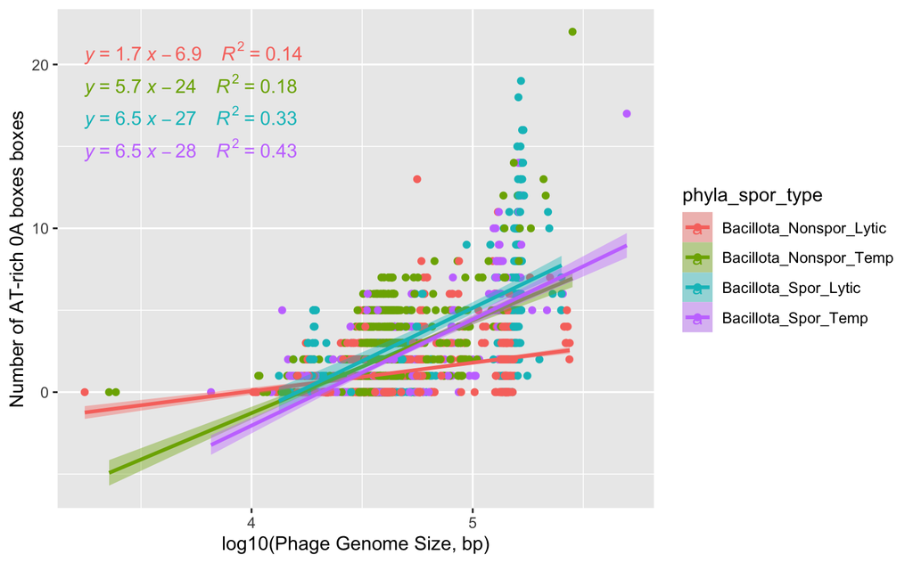

```r
ggplot(baci, aes(genome,sum, fill=phyla_spor_type, colour = phyla_spor_type)) +
  geom_point() +
   geom_smooth(method="lm")+ # Add regression line
 stat_regline_equation(aes(label = paste(..eq.label.., ..rr.label.., sep = "~~~~")),
                        label.x.npc = "left", label.y.npc = "top" )   + ylab("Number of AT-rich 0A boxes boxes") +xlab("log10(Phage Genome Size, bp)")# Add
ggsave(here("lab_pres/UpstreamFilt35_Baci0AReg.png"))
```

```r
spor.counts <- baci %>% group_by(sporulation) %>% summarise(num.phage=sum(tally), total.0A=sum(sum), mean.0A=mean(sum), hits.0A=sum(hit))

spor.counts$perc.hit <- spor.counts$hits.0A/spor.counts$num.phage

spor.counts
```

| sporulation | num.phage | total.0A | mean.0A | hits.0A | perc.hit |
| --- | --- | --- | --- | --- | --- |
| Nonspor | 2532 | 4590 | 1.812796 | 1939 | 0.7657978 |
| Spor | 811 | 2628 | 3.240444 | 664 | 0.8187423 |

```r
NA
```

```r
spor.stat <- c('Spore', 'Non-spore')
outcome <- c('Hits', 'None')
bacil.hits <- matrix(c(736, 75, 2234, 298), nrow=2, ncol=2, byrow=TRUE)
dimnames(bacil.hits) <- list('Spore'=spor.stat, 'Outcome'=outcome)
bacil.hits
```

```
           Outcome
Spore       Hits None
  Spore      736   75
  Non-spore 2234  298
```

```r
library(epitools)

fisher.test(bacil.hits)
```

```
    Fisher's Exact Test for Count Data

data:  bacil.hits
p-value = 0.04714
alternative hypothesis: true odds ratio is not equal to 1
95 percent confidence interval:
 0.9982116 1.7329346
sample estimates:
odds ratio
  1.308888
```

```r
oddsratio(bacil.hits)
```

```
$data
           Outcome
Spore       Hits None Total
  Spore      736   75   811
  Non-spore 2234  298  2532
  Total     2970  373  3343

$measure
           odds ratio with 95% C.I.
Spore       estimate    lower   upper
  Spore     1.000000       NA      NA
  Non-spore 1.306972 1.006351 1.71714

$p.value
           two-sided
Spore       midp.exact fisher.exact chi.square
  Spore             NA           NA         NA
  Non-spore 0.04460157   0.04713798 0.04715564

$correction
[1] FALSE

attr(,"method")
[1] "median-unbiased estimate & mid-p exact CI"
```

```r
virbac <- subset(baci, baci$predicted_label=="virulent")

life.counts <- virbac %>% group_by(sporulation) %>% summarise(num.phage=sum(tally), total.0A=sum(sum), mean.0A=mean(sum), hits.0A=sum(hit))

life.counts$perc.hit <- life.counts$hits.0A/life.counts$num.phage

life.counts
```

| sporulation | num.phage | total.0A | mean.0A | hits.0A | perc.hit |
| --- | --- | --- | --- | --- | --- |
| Nonspor | 1097 | 1499 | 1.366454 | 719 | 0.6554239 |
| Spor | 357 | 1661 | 4.652661 | 312 | 0.8739496 |

```r
spor.stat <- c('Spore', 'Non-spore')
outcome <- c('Hits', 'None')
vir.hits <- matrix(c(338, 19, 1097, 246), nrow=2, ncol=2, byrow=TRUE)
dimnames(vir.hits) <- list('Spore'=spor.stat, 'Outcome'=outcome)

vir.hits
```

```
           Outcome
Spore       Hits None
  Spore      338   19
  Non-spore 1097  246
```

```r
library(epitools)
fisher.test(vir.hits)
```

```
    Fisher's Exact Test for Count Data

data:  vir.hits
p-value = 7.378e-11
alternative hypothesis: true odds ratio is not equal to 1
95 percent confidence interval:
 2.451394 6.843502
sample estimates:
odds ratio
  3.986701
```

```r
oddsratio(vir.hits)
```

```
$data
           Outcome
Spore       Hits None Total
  Spore      338   19   357
  Non-spore 1097  246  1343
  Total     1435  265  1700

$measure
           odds ratio with 95% C.I.
Spore       estimate    lower    upper
  Spore     1.000000       NA       NA
  Non-spore 3.957262 2.506967 6.626532

$p.value
           two-sided
Spore         midp.exact fisher.exact   chi.square
  Spore               NA           NA           NA
  Non-spore 4.492851e-11 7.377785e-11 1.784964e-09

$correction
[1] FALSE

attr(,"method")
[1] "median-unbiased estimate & mid-p exact CI"
```

```r
tempbac <- subset(baci, baci$predicted_label=="temperate")

tlife.counts <- tempbac %>% group_by(sporulation) %>% summarise(num.phage=sum(tally), total.0A=sum(sum), mean.0A=mean(sum), hits.0A=sum(hit))

tlife.counts$perc.hit <- tlife.counts$hits.0A/tlife.counts$num.phage

tlife.counts
```

| sporulation | num.phage | total.0A | mean.0A | hits.0A | perc.hit |
| --- | --- | --- | --- | --- | --- |
| Nonspor | 1435 | 3091 | 2.154007 | 1220 | 0.8501742 |
| Spor | 454 | 967 | 2.129956 | 352 | 0.7753304 |

```r
spor.stat <- c('Spore', 'Non-spore')
outcome <- c('Hits', 'None')
temp.hits <- matrix(c(398, 56, 1383, 52), nrow=2, ncol=2, byrow=TRUE)
dimnames(temp.hits) <- list('Spore'=spor.stat, 'Outcome'=outcome)

temp.hits
```

```
           Outcome
Spore       Hits None
  Spore      398   56
  Non-spore 1383   52
```

```r
library(epitools)
fisher.test(temp.hits)
```

```
    Fisher's Exact Test for Count Data

data:  temp.hits
p-value = 1.385e-10
alternative hypothesis: true odds ratio is not equal to 1
95 percent confidence interval:
 0.1766936 0.4042270
sample estimates:
odds ratio
 0.2674352
```

```r
oddsratio(temp.hits)
```

```
$data
           Outcome
Spore       Hits None Total
  Spore      398   56   454
  Non-spore 1383   52  1435
  Total     1781  108  1889

$measure
           odds ratio with 95% C.I.
Spore        estimate    lower     upper
  Spore     1.0000000       NA        NA
  Non-spore 0.2674937 0.179992 0.3969365

$p.value
           two-sided
Spore        midp.exact fisher.exact   chi.square
  Spore              NA           NA           NA
  Non-spore 1.32748e-10 1.385072e-10 3.217975e-12

$correction
[1] FALSE

attr(,"method")
[1] "median-unbiased estimate & mid-p exact CI"
```

```r
sporbac <- subset(baci, baci$sporulation=="Spor")

spor.life <- sporbac %>% group_by(predicted_label) %>% summarise(num.phage=sum(tally), total.0A=sum(sum), mean.0A=mean(sum), hits.0A=sum(hit))

spor.life
```

| predicted_label | num.phage | total.0A | mean.0A | hits.0A |
| --- | --- | --- | --- | --- |
| temperate | 454 | 967 | 2.129956 | 352 |
| virulent | 357 | 1661 | 4.652661 | 312 |

```r
NA
```

```r
## this is spor temp vs. spor lytic of bacil
spor.stat <- c('Spore', 'Non-spore')
outcome <- c('Hits', 'None')
temp.hits <- matrix(c(357, 23, 454, 63), nrow=2, ncol=2, byrow=TRUE)
dimnames(temp.hits) <- list('Spore'=spor.stat, 'Outcome'=outcome)

temp.hits
```

```
           Outcome
Spore       Hits None
  Spore      357   23
  Non-spore  454   63
```

```r
library(epitools)
fisher.test(temp.hits)
```

```
    Fisher's Exact Test for Count Data

data:  temp.hits
p-value = 0.001899
alternative hypothesis: true odds ratio is not equal to 1
95 percent confidence interval:
 1.286520 3.711636
sample estimates:
odds ratio
  2.152109
```

```r
oddsratio(temp.hits)
```

```
$data
           Outcome
Spore       Hits None Total
  Spore      357   23   380
  Non-spore  454   63   517
  Total      811   86   897

$measure
           odds ratio with 95% C.I.
Spore       estimate    lower    upper
  Spore     1.000000       NA       NA
  Non-spore 2.143206 1.320225 3.597265

$p.value
           two-sided
Spore        midp.exact fisher.exact  chi.square
  Spore              NA           NA          NA
  Non-spore 0.001767875  0.001898591 0.002050377

$correction
[1] FALSE

attr(,"method")
[1] "median-unbiased estimate & mid-p exact CI"
```